# ggplot2::scale_x_reverse()

# Function of the Week:

Olivia Reynolds

2023-02-08

# Submission Instructions

Please sign up for a function here: https://docs.google.com/spreadsheets/d/1-RWAQTlLwttjFuZVAtSs8OiHIwu6AZLUdWugIHHTWVo/edit?usp=sharing

For this assignment, please submit both the `.Rmd` and the `.html` files. I will add it to the website. Remove your name from the Rmd if you do not wish it shared. If you select a function which was [presented last year](https://sph-r-programming.netlify.app/functions/), please develop your own examples and content.

# `scale_x_reverse()`

In this document, I will introduce the scale_x_reverse() function and show what it’s for.

```r
#load tidyverse up
library(tidyverse)
```

```r
library(ggplot2)
#example dataset
library(palmerpenguins)
data(penguins)
```

## What is it for?

> scale_x_reverse(), reverses the x axis of the data. Typically the data would be ordered from smallest to largest value, but this function would arrange the data from largest to smallest values. In the example below I’ll show what the plot looks like without the scale_x_reverse() function and then how the plot changes when the function is implemented into the command.

##Example 1: Penguin Data Set

##Plot without scale_x_reverse() function

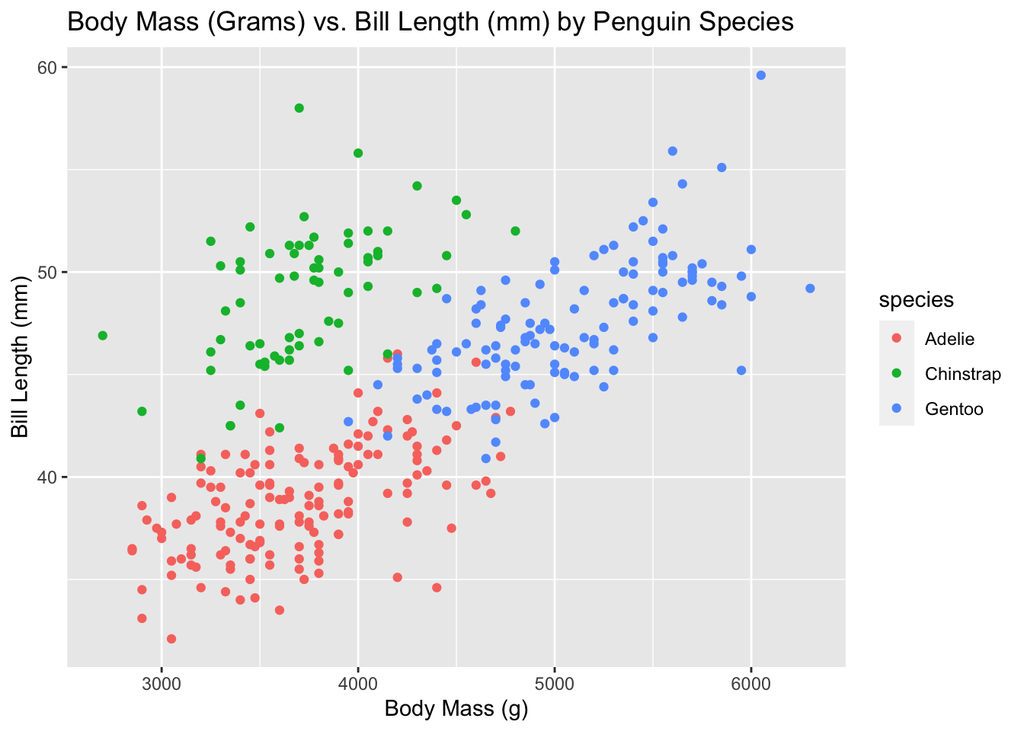

```r
ggplot(penguins) +

  aes(x = body_mass_g,
      y = bill_length_mm,
      color = species)+
labs(title= "Body Mass (Grams) vs. Bill Length (mm) by Penguin Species", y = "Bill Length (mm)", x = "Body Mass (g)")+
  geom_point()
```

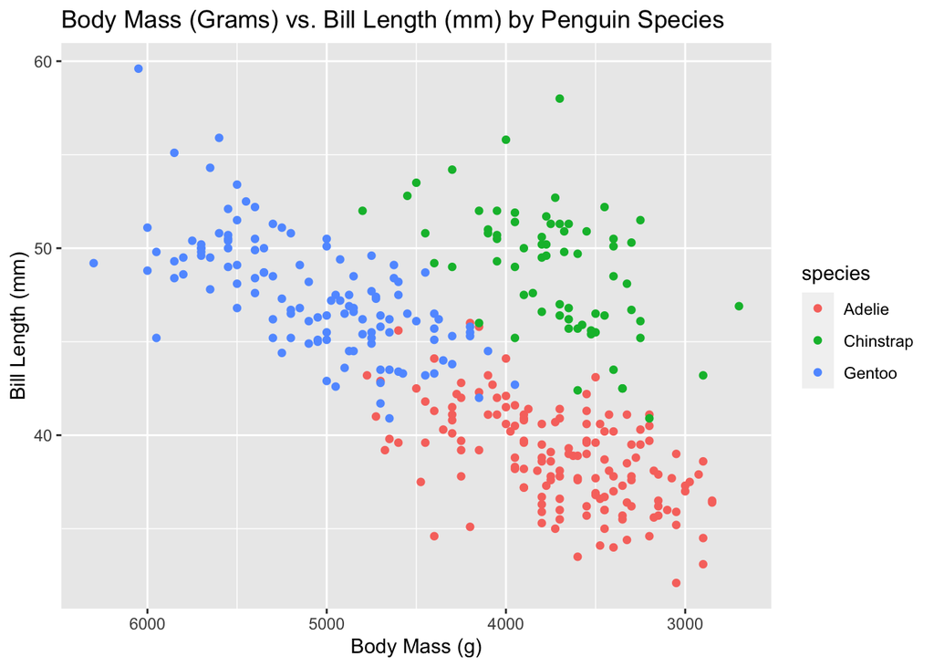

```r
ggplot(penguins) +

  aes(x = body_mass_g,
      y = bill_length_mm,
      color = species) +
  labs(title= "Body Mass (Grams) vs. Bill Length (mm) by Penguin Species", y = "Bill Length (mm)", x = "Body Mass (g)")+
  geom_point() +
    scale_x_reverse()
```

##Without scale_x_reverse() Function

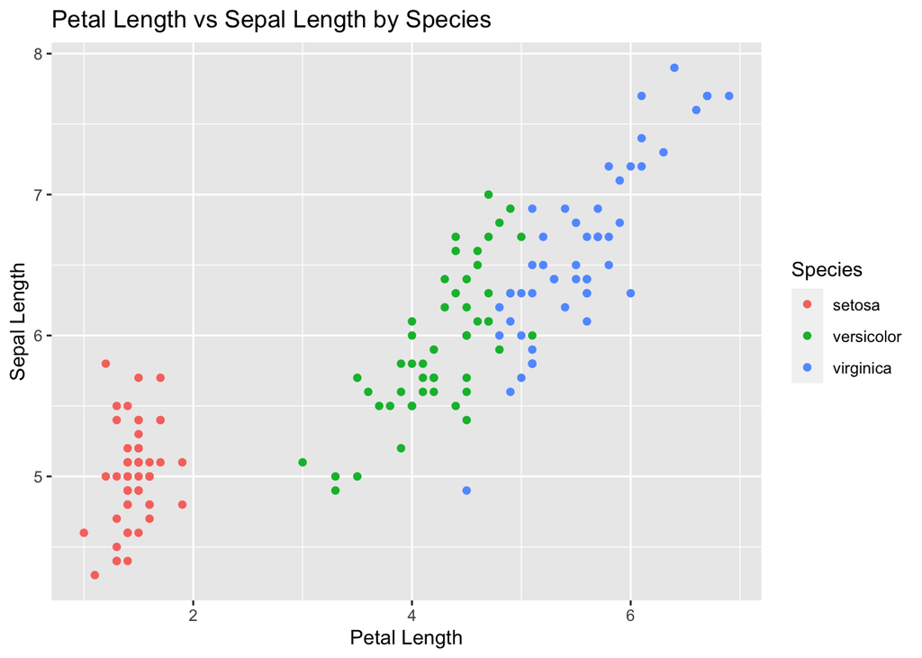

```r
data("iris")

ggplot(iris) +
  aes(x = Petal.Length,
      y = Sepal.Length,
      color = Species) +
  labs(title= "Petal Length vs Sepal Length by Species", y = "Sepal Length", x = "Petal Length")+
  geom_point()
```

##With scale_x_reverse() Function

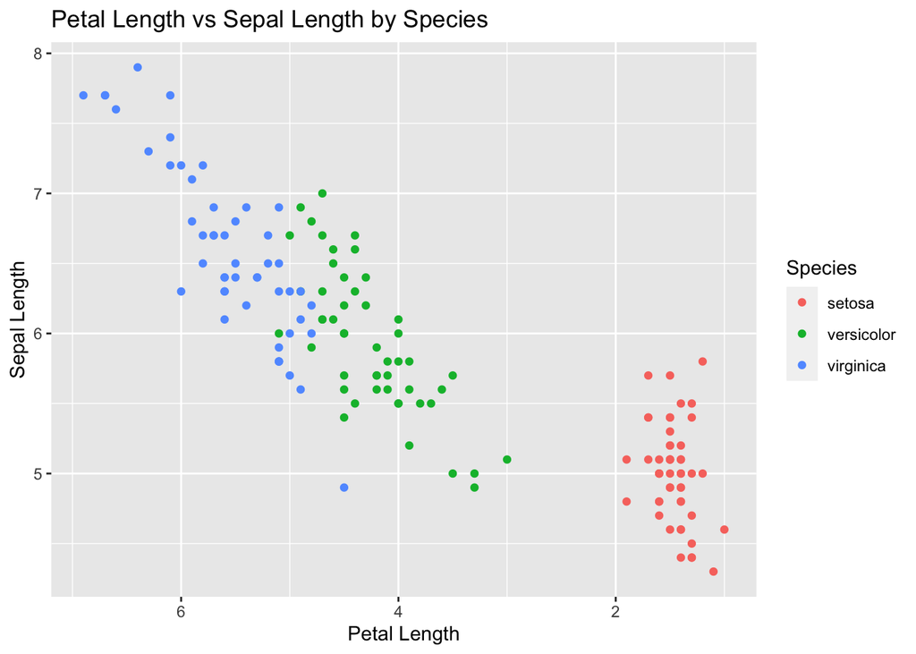

```r
data("iris")

ggplot(iris) +
  aes(x = Petal.Length,
      y = Sepal.Length,
      color = Species) +
  labs(title= "Petal Length vs Sepal Length by Species", y = "Sepal Length", x = "Petal Length")+
  geom_point() +
  scale_x_reverse()
```

## Is it helpful?

> I think this function could be useful as a different way to view a data set. Maybe it would be easier to use certain correlation patterns with this function. I think it will be a good function to know, but I don’t think it is the best thing since sliced bread.

Last updated on March 5, 2023

[Edit this page](https://github.com/jminnier/sph_r_programming_site/edit/master/content/functions/ggplot2_scale_x_reverse.html)